# Different data formats

Di Cook, Heike Hofmann  
1/13/2014

### Outline

- Data formats: ascii, binary, special
- Rearranging data for analysis
- Workflow
- Text Editors
- Formatting code

### ASCII

- **A**merican **S**tandard **C**ode for **I**nformation **I**nterchange (1960, Bell Data)
- enables text representation on computers, communication devices
- encodes 128 specified characters, numbers 0-9, letters a-z, A-Z, some basic punctuation, and control codes
- 7-bit binary integers

### ASCII REFERENCE CARD

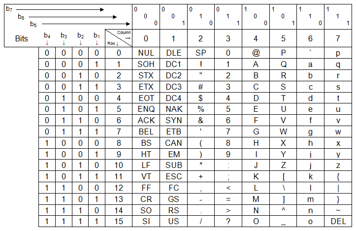

Link to image source

### ASCII

- printable characters: 100 0001=A, 100 0010=B, 110 0001=a, 110 0010=b, …
- first 32 chars are for control, e.g. 000 1000=BS=backspace, 111 1111=DEL=delete,
- differences: end of line in Windows is LF CR (Line feed, carriage return), and only LF on Mac OS and UNIX systems
- Advantage of ascii: human readble, less prone to error/can be humanly checked

[http://en.wikipedia.org/wiki/Ascii]

### COMPUTERS and HEXADECIMAL

Grouping of bits together is necessary to represent numbers, use hexadecimal system, base 16

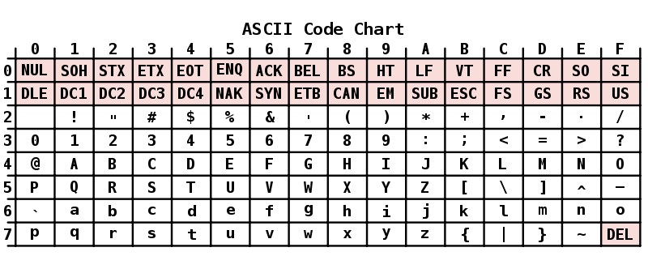

### COMPUTERS and HEXADECIMAL

- The number 3.141593 is represented in file as 33 2E 31 34 31 35 39 33 i.e needs 8 bytes (= 64 bit = space needed to represent binary number with 16 digits precision)
- Also need separators: comma, tab, pipe (|)

### ASCII and R

- `read.table()`, `read.csv()` reads ascii files
- `write.table()` writes ascii files

### BINARY

- No restriction in terms on content, streams of bytes
- Advantage: Generally much smaller files, and with compression even smaller, e.g. nasadata.csv is 3.7Mb, nasadata.rds is 288kb
- Disadvantage: Can be machine-dependent

### BINARY and R

- `saveRDS()` saves a single R object in binary format
- `save()` saves all objects
- `readRDS()` reads R binary file

### EXAMPLE

```r
d1 <- read.csv("../data/nasadata.csv")
dim(d1)
```

```
[1] 41472    14
```

```r
d1[1,]
```

```
  time y x   lat   long       date cloudhigh cloudlow cloudmid ozone pressure
1    1 1 1 -21.2 -113.8 1995-01-01       0.5       31        2   260     1000
  surftemp temperature  id
1    297.4       296.9 1-1
```

### EXAMPLE

```r
d2 <- readRDS("../data/nasadata.rds")
dim(d2)
```

```
[1] 41472    17
```

```r
d2[1,]
```

```
  time y x   lat   long       date cloudhigh cloudlow cloudmid ozone pressure
1    1 1 1 -21.2 -113.8 1995-01-01       0.5       31        2   260     1000
  surftemp temperature  id day month year
1    297.4       296.9 1-1   0     1 1995
```

### AWKWARD TEXT FORMATS and R

```r
temp.all<-read.table(
  "../data/9641C_201112_raw.avg")
dim(temp.all)
```

```
[1] 132644     14
```

### AWKWARD TEXT FORMATS and R

```r
colnames(temp.all)<-c("year", "jan", "feb", "mar", "apr", "may", "jun", "jul", "aug", "sep", "oct", "nov", "dec", "ann")
head(temp.all)
```

```
       year   jan   feb mar   apr may jun jul aug sep oct   nov   dec   ann
1 1.108e+09   469   426 571   638 710 789 813 810 786 613 -9999 -9999 -9999
2 1.108e+09   476   513 548 -9999 766 787 802 815 744 645   578   456 -9999
3 1.108e+09   452   553 675   642 695 817 816 779 753 658 -9999 -9999 -9999
4 1.108e+09 -9999 -9999 561   669 748 786 819 837 806 738   588   518 -9999
5 1.108e+09 -9999   544 543   641 723 798 809 818 819 700   549   576 -9999
6 1.108e+09   538   648 618   713 764 807 812 786 784 695   663   477   692
```

### AWKWARD TEXT FORMATS and R

```r
newpbi <- read.csv("../data/newpbi.csv")
dim(newpbi)
```

```
[1] 30 46
```

```r
newpbi[1:4,1:4]
```

```
              Site Type Araneae Acari
1 C-Turtlehead Fen    1      15     0
2        Doolittle    1       3     1
3           Judson    1      23     0
4     Liska-Stanek    1       9     0
```

### OTHER TEXT and R

- Fixed formats can be read with `read.fwf()`
- For really ugly formatted text, single words can be extracted using `scan()`

### HTML FILES

- A lot of data is available online in the form of html tables
- Extracting the data requires recognizing the html table format, and stripping off the html
- The package `xml` helps with this

### HTML FILES

Pulling election polls off the web…

```r
library(XML)
src ="http://www.realclearpolitics.com/epolls/2012/president/us/republican_presidential_nomination-1452.html"
tables <- readHTMLTable(src)
library(plyr)
ldply(tables, dim)
```

```
    .id  V1 V2
1  NULL   2  4
2  NULL   1  4
3  NULL   5 13
4  NULL   4  8
5  NULL   1  2
6  NULL   2  8
7  NULL   1  6
8  NULL   1  2
9  NULL   2 12
10 NULL   1 12
11 NULL   1  2
12 NULL   2 12
13 NULL   1 12
14 NULL   1  2
15 NULL 197 13
```

### HTML FILES

```r
polls <- tables[[15]]
head(polls) # still some work to do ...
```

```
                  Poll        Date  Sample MoE Romney  Santorum  Gingrich
1          RCP Average  4/9 - 4/17      --  --    52.8        --      19.0
2    CBS News/NY Times 4/13 - 4/17  268 RV 6.0      54        --        20
3 CNN/Opinion Research 4/13 - 4/15   473 A 4.5      57        --        19
4              PPP (D) 4/12 - 4/15  742 RV 3.6      54        --        24
5             FOX News  4/9 - 4/11  376 RV 5.0      46        15        13
6         Pew Research  4/4 - 4/15 1099 RV 3.4      42        21        13
  Paul  Perry  Huntsman  Bachmann  Cain        Spread
1  15.0     --        --        --    -- Romney +33.8
2    12     --        --        --    --   Romney +34
3    18     --        --        --    --   Romney +38
4    14     --        --        --    --   Romney +30
5    16     --        --        --    --   Romney +30
6    13     --        --        --    --   Romney +21
```

### OTHER BINARY FORMATS and R

- Package `foreign`: Data export/import for other (statistical) software: Stata, Epi, Octave, SPSS, Systat, SAS
- Package `XLConnect` import/export with Excel spreadsheets e.g. web index data at http://www.visualizing.org/datasets/web-index-2013

```r
library(foreign)
knights <- read.spss("../data/knightfoundation2008sotcdata.por")
str(knights)
```

[output not shown]

[output cut: 560 more lines]

[output not shown]

### JSON

- **J**avaScript **O**bject **N**otation [JSON](http://json.org/) is a lightweight data interchange format, becoming popular
- Human readable and writable
- Utilized by many web APIs, e.g. tumblr, twitter and Census Bureau

e.g. result from get query in JSON format:

[[“P0010001”,“NAME”,“state”], [“710231”,“Alaska”,“02”], [“4779736”,“Alabama”,“01”], [“2915918”,“Arkansas”,“05”], [“6392017”,“Arizona”,“04”], [“37253956”,“California”,“06”]]

i.e. vector of vector format - focus is on individual rows in a data set, whereas R puts emphasis on individual columns (data set is list of vectors).

### Example: Census Bureau API

```r
library(devtools)
install_github("cbapi", "heike")
library(cbapi)
setkey("7f784587c3918611ad6ca67188d9b269b3558dd4") # my key - if you want to use this, get your own :)
```

```
key is saved, now you will be able to access data through the API.
```

```r
# population based on 2010 Census:
popstate <- read.census(sprintf("http://api.census.gov/data/2010/sf1?key=%s&get=P0010001,NAME&for=state:*", getkey()))
head(popstate)
```

```
  P0010001       NAME state
1  4779736    Alabama    01
2   710231     Alaska    02
3  6392017    Arizona    04
4  2915918   Arkansas    05
5 37253956 California    06
6  5029196   Colorado    08
```

### WHY?

- To solve a problem, may need to collate data from multiple sources
- Rearranging and merging data from different sources helps to pull together the data necessary to solve the problem

### READING

[Reshaping data: http://www.jstatsoft.org/v21/i12/paper](http://www.jstatsoft.org/v21/i12/paper)

- What does it mean to melt data?
- Why cast it in different forms?
- Where would this be useful?

Make a blog entry by 3pm Wednesday, Jan 15.